# Risk Factor Analysis

## Outcome Variable

**Outcome Variable:** ever_sstunted

## Predictor Variables

**Intervention Variable:** mhtcm

**Adjustment Set:**

unadjusted

## Stratifying Variables

The analysis was stratified on these variable(s):

- agecat
- studyid
- country

## Data Summary

| agecat | studyid | country | mhtcm | ever_sstunted | n_cell | n |
| --- | --- | --- | --- | --- | --- | --- |
| 0-24 months | ki0047075b-MAL-ED | BANGLADESH | >=155 cm | 0 | 22 | 254 |
| 0-24 months | ki0047075b-MAL-ED | BANGLADESH | >=155 cm | 1 | 3 | 254 |
| 0-24 months | ki0047075b-MAL-ED | BANGLADESH | <151 cm | 0 | 114 | 254 |
| 0-24 months | ki0047075b-MAL-ED | BANGLADESH | <151 cm | 1 | 49 | 254 |
| 0-24 months | ki0047075b-MAL-ED | BANGLADESH | [151-155) cm | 0 | 62 | 254 |
| 0-24 months | ki0047075b-MAL-ED | BANGLADESH | [151-155) cm | 1 | 4 | 254 |
| 0-24 months | ki0047075b-MAL-ED | BRAZIL | >=155 cm | 0 | 119 | 222 |
| 0-24 months | ki0047075b-MAL-ED | BRAZIL | >=155 cm | 1 | 11 | 222 |
| 0-24 months | ki0047075b-MAL-ED | BRAZIL | <151 cm | 0 | 47 | 222 |
| 0-24 months | ki0047075b-MAL-ED | BRAZIL | <151 cm | 1 | 6 | 222 |
| 0-24 months | ki0047075b-MAL-ED | BRAZIL | [151-155) cm | 0 | 34 | 222 |
| 0-24 months | ki0047075b-MAL-ED | BRAZIL | [151-155) cm | 1 | 5 | 222 |
| 0-24 months | ki0047075b-MAL-ED | INDIA | >=155 cm | 0 | 46 | 242 |
| 0-24 months | ki0047075b-MAL-ED | INDIA | >=155 cm | 1 | 9 | 242 |
| 0-24 months | ki0047075b-MAL-ED | INDIA | <151 cm | 0 | 79 | 242 |
| 0-24 months | ki0047075b-MAL-ED | INDIA | <151 cm | 1 | 36 | 242 |
| 0-24 months | ki0047075b-MAL-ED | INDIA | [151-155) cm | 0 | 59 | 242 |
| 0-24 months | ki0047075b-MAL-ED | INDIA | [151-155) cm | 1 | 13 | 242 |
| 0-24 months | ki0047075b-MAL-ED | NEPAL | >=155 cm | 0 | 41 | 238 |
| 0-24 months | ki0047075b-MAL-ED | NEPAL | >=155 cm | 1 | 0 | 238 |
| 0-24 months | ki0047075b-MAL-ED | NEPAL | <151 cm | 0 | 117 | 238 |
| 0-24 months | ki0047075b-MAL-ED | NEPAL | <151 cm | 1 | 16 | 238 |
| 0-24 months | ki0047075b-MAL-ED | NEPAL | [151-155) cm | 0 | 59 | 238 |
| 0-24 months | ki0047075b-MAL-ED | NEPAL | [151-155) cm | 1 | 5 | 238 |
| 0-24 months | ki0047075b-MAL-ED | PERU | >=155 cm | 0 | 49 | 290 |
| 0-24 months | ki0047075b-MAL-ED | PERU | >=155 cm | 1 | 11 | 290 |
| 0-24 months | ki0047075b-MAL-ED | PERU | <151 cm | 0 | 124 | 290 |
| 0-24 months | ki0047075b-MAL-ED | PERU | <151 cm | 1 | 45 | 290 |
| 0-24 months | ki0047075b-MAL-ED | PERU | [151-155) cm | 0 | 54 | 290 |
| 0-24 months | ki0047075b-MAL-ED | PERU | [151-155) cm | 1 | 7 | 290 |

[output cut: 240 more lines]

The following strata were considered:

- agecat: 0-24 months, studyid: ki0047075b-MAL-ED, country: BANGLADESH
- agecat: 0-24 months, studyid: ki0047075b-MAL-ED, country: BRAZIL
- agecat: 0-24 months, studyid: ki0047075b-MAL-ED, country: INDIA
- agecat: 0-24 months, studyid: ki0047075b-MAL-ED, country: NEPAL
- agecat: 0-24 months, studyid: ki0047075b-MAL-ED, country: PERU
- agecat: 0-24 months, studyid: ki0047075b-MAL-ED, country: SOUTH AFRICA
- agecat: 0-24 months, studyid: ki0047075b-MAL-ED, country: TANZANIA, UNITED REPUBLIC OF
- agecat: 0-24 months, studyid: ki1000304b-SAS-CompFeed, country: INDIA
- agecat: 0-24 months, studyid: ki1000304b-SAS-FoodSuppl, country: INDIA
- agecat: 0-24 months, studyid: ki1017093-NIH-Birth, country: BANGLADESH
- agecat: 0-24 months, studyid: ki1017093b-PROVIDE, country: BANGLADESH
- agecat: 0-24 months, studyid: ki1017093c-NIH-Crypto, country: BANGLADESH
- agecat: 0-24 months, studyid: ki1066203-TanzaniaChild2, country: TANZANIA, UNITED REPUBLIC OF
- agecat: 0-24 months, studyid: ki1101329-Keneba, country: GAMBIA
- agecat: 0-24 months, studyid: ki1112895-Guatemala BSC, country: GUATEMALA
- agecat: 0-24 months, studyid: ki1112895-iLiNS-Zinc, country: BURKINA FASO
- agecat: 0-24 months, studyid: ki1119695-PROBIT, country: BELARUS
- agecat: 0-24 months, studyid: ki1126311-ZVITAMBO, country: ZIMBABWE
- agecat: 0-24 months, studyid: ki1135781-COHORTS, country: GUATEMALA
- agecat: 0-24 months, studyid: ki1135781-COHORTS, country: INDIA
- agecat: 0-24 months, studyid: ki1135781-COHORTS, country: PHILIPPINES
- agecat: 0-24 months, studyid: ki1148112-LCNI-5, country: MALAWI
- agecat: 0-24 months, studyid: kiGH5241-JiVitA-3, country: BANGLADESH
- agecat: 0-6 months, studyid: ki0047075b-MAL-ED, country: BANGLADESH
- agecat: 0-6 months, studyid: ki0047075b-MAL-ED, country: BRAZIL
- agecat: 0-6 months, studyid: ki0047075b-MAL-ED, country: INDIA
- agecat: 0-6 months, studyid: ki0047075b-MAL-ED, country: NEPAL
- agecat: 0-6 months, studyid: ki0047075b-MAL-ED, country: PERU
- agecat: 0-6 months, studyid: ki0047075b-MAL-ED, country: SOUTH AFRICA
- agecat: 0-6 months, studyid: ki0047075b-MAL-ED, country: TANZANIA, UNITED REPUBLIC OF
- agecat: 0-6 months, studyid: ki1000304b-SAS-CompFeed, country: INDIA
- agecat: 0-6 months, studyid: ki1000304b-SAS-FoodSuppl, country: INDIA
- agecat: 0-6 months, studyid: ki1017093-NIH-Birth, country: BANGLADESH
- agecat: 0-6 months, studyid: ki1017093b-PROVIDE, country: BANGLADESH
- agecat: 0-6 months, studyid: ki1017093c-NIH-Crypto, country: BANGLADESH
- agecat: 0-6 months, studyid: ki1066203-TanzaniaChild2, country: TANZANIA, UNITED REPUBLIC OF
- agecat: 0-6 months, studyid: ki1101329-Keneba, country: GAMBIA
- agecat: 0-6 months, studyid: ki1112895-Guatemala BSC, country: GUATEMALA
- agecat: 0-6 months, studyid: ki1119695-PROBIT, country: BELARUS
- agecat: 0-6 months, studyid: ki1126311-ZVITAMBO, country: ZIMBABWE
- agecat: 0-6 months, studyid: ki1135781-COHORTS, country: GUATEMALA
- agecat: 0-6 months, studyid: ki1135781-COHORTS, country: INDIA
- agecat: 0-6 months, studyid: ki1135781-COHORTS, country: PHILIPPINES
- agecat: 0-6 months, studyid: ki1148112-LCNI-5, country: MALAWI
- agecat: 0-6 months, studyid: kiGH5241-JiVitA-3, country: BANGLADESH

### Dropped Strata

Some strata were dropped due to rare outcomes:

- agecat: 0-24 months, studyid: ki0047075b-MAL-ED, country: BANGLADESH
- agecat: 0-24 months, studyid: ki0047075b-MAL-ED, country: NEPAL
- agecat: 0-24 months, studyid: ki1112895-Guatemala BSC, country: GUATEMALA
- agecat: 0-6 months, studyid: ki0047075b-MAL-ED, country: BANGLADESH
- agecat: 0-6 months, studyid: ki0047075b-MAL-ED, country: BRAZIL
- agecat: 0-6 months, studyid: ki0047075b-MAL-ED, country: INDIA
- agecat: 0-6 months, studyid: ki0047075b-MAL-ED, country: NEPAL
- agecat: 0-6 months, studyid: ki0047075b-MAL-ED, country: SOUTH AFRICA
- agecat: 0-6 months, studyid: ki1000304b-SAS-FoodSuppl, country: INDIA
- agecat: 0-6 months, studyid: ki1017093b-PROVIDE, country: BANGLADESH
- agecat: 0-6 months, studyid: ki1112895-Guatemala BSC, country: GUATEMALA

## Methods Detail

We’re interested in the causal parameters $E[Y_a]$ for all values of $a \in \mathcal{A}$. These parameters represent the mean outcome if, possibly contrary to fact, we intervened to set all units to have $A=a$. Under the randomization and positivity assumptions, these are identified by the statistical parameters $\psi_a=E_W[E_{Y|A,W}(Y|A=a,W)]$. In addition, we’re interested in the mean of $Y$, $E[Y]$ under no intervention (the observed mean). We will estimate these parameters by using SuperLearner to fit the relevant likelihood factors – $E_{Y|A,W}(Y|A=a,W)$ and $p(A=a|W)$, and then updating our likelihood fit using a joint TMLE.

For unadjusted analyses ($W=\{\}$), initial likelihoods were estimated using Lrnr_glm to estimate the simple $E(Y|A)$ and Lrnr_mean to estimate $p(A)$. For adjusted analyses, a small library containing Lrnr_glmnet, Lrnr_xgboost, and Lrnr_mean was used.

Having estimated these parameters, we will then use the delta method to estimate relative risks and attributable risks relative to a prespecified baseline level of $A$.

# Results Detail

## Results Plots

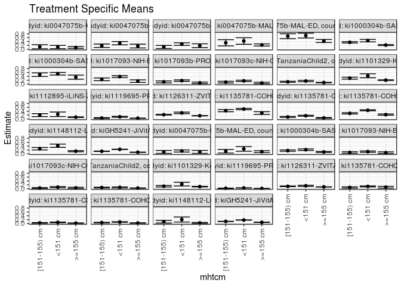

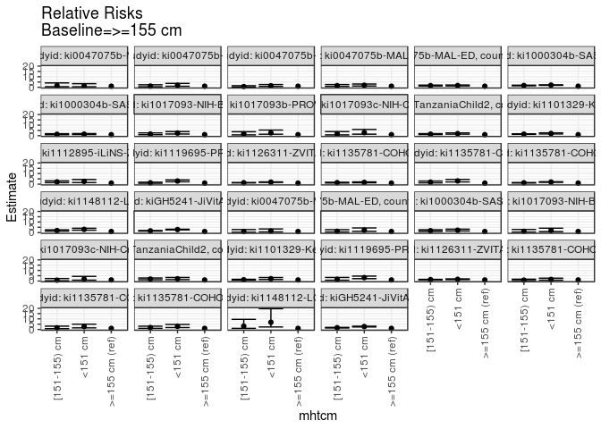

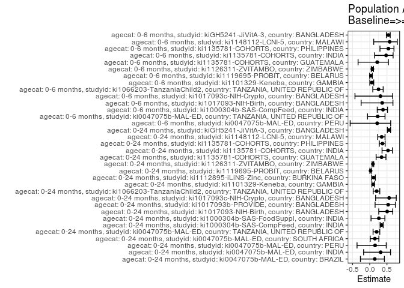

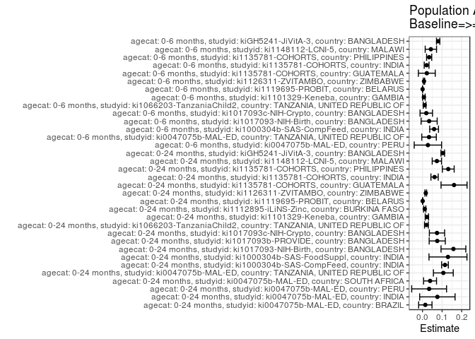

## Results Table

### Parameter: TSM

| agecat | studyid | country | intervention_level | baseline_level | estimate | ci_lower | ci_upper |
| --- | --- | --- | --- | --- | --- | --- | --- |
| 0-24 months | ki0047075b-MAL-ED | BRAZIL | >=155 cm | NA | 0.0846154 | 0.0366660 | 0.1325648 |
| 0-24 months | ki0047075b-MAL-ED | BRAZIL | <151 cm | NA | 0.1132075 | 0.0277128 | 0.1987022 |
| 0-24 months | ki0047075b-MAL-ED | BRAZIL | [151-155) cm | NA | 0.1282051 | 0.0230438 | 0.2333664 |
| 0-24 months | ki0047075b-MAL-ED | INDIA | >=155 cm | NA | 0.1636364 | 0.0656640 | 0.2616087 |
| 0-24 months | ki0047075b-MAL-ED | INDIA | <151 cm | NA | 0.3130435 | 0.2281127 | 0.3979743 |
| 0-24 months | ki0047075b-MAL-ED | INDIA | [151-155) cm | NA | 0.1805556 | 0.0915235 | 0.2695876 |
| 0-24 months | ki0047075b-MAL-ED | PERU | >=155 cm | NA | 0.1833333 | 0.0852567 | 0.2814100 |
| 0-24 months | ki0047075b-MAL-ED | PERU | <151 cm | NA | 0.2662722 | 0.1995170 | 0.3330274 |
| 0-24 months | ki0047075b-MAL-ED | PERU | [151-155) cm | NA | 0.1147541 | 0.0346326 | 0.1948756 |
| 0-24 months | ki0047075b-MAL-ED | SOUTH AFRICA | >=155 cm | NA | 0.2205882 | 0.1635832 | 0.2775933 |
| 0-24 months | ki0047075b-MAL-ED | SOUTH AFRICA | <151 cm | NA | 0.4242424 | 0.2553058 | 0.5931790 |
| 0-24 months | ki0047075b-MAL-ED | SOUTH AFRICA | [151-155) cm | NA | 0.3333333 | 0.1721981 | 0.4944686 |
| 0-24 months | ki0047075b-MAL-ED | TANZANIA, UNITED REPUBLIC OF | >=155 cm | NA | 0.4248366 | 0.3463566 | 0.5033166 |
| 0-24 months | ki0047075b-MAL-ED | TANZANIA, UNITED REPUBLIC OF | <151 cm | NA | 0.7058824 | 0.5805857 | 0.8311790 |
| 0-24 months | ki0047075b-MAL-ED | TANZANIA, UNITED REPUBLIC OF | [151-155) cm | NA | 0.6730769 | 0.5453297 | 0.8008241 |
| 0-24 months | ki1000304b-SAS-CompFeed | INDIA | >=155 cm | NA | 0.2150350 | 0.1882546 | 0.2418153 |
| 0-24 months | ki1000304b-SAS-CompFeed | INDIA | <151 cm | NA | 0.4433198 | 0.3801789 | 0.5064608 |
| 0-24 months | ki1000304b-SAS-CompFeed | INDIA | [151-155) cm | NA | 0.3577713 | 0.3213083 | 0.3942342 |
| 0-24 months | ki1000304b-SAS-FoodSuppl | INDIA | >=155 cm | NA | 0.3589744 | 0.2523880 | 0.4655608 |
| 0-24 months | ki1000304b-SAS-FoodSuppl | INDIA | <151 cm | NA | 0.5363636 | 0.4703875 | 0.6023398 |
| 0-24 months | ki1000304b-SAS-FoodSuppl | INDIA | [151-155) cm | NA | 0.4864865 | 0.3933908 | 0.5795822 |
| 0-24 months | ki1017093-NIH-Birth | BANGLADESH | >=155 cm | NA | 0.1538462 | 0.0884174 | 0.2192749 |
| 0-24 months | ki1017093-NIH-Birth | BANGLADESH | <151 cm | NA | 0.3879781 | 0.3380161 | 0.4379402 |
| 0-24 months | ki1017093-NIH-Birth | BANGLADESH | [151-155) cm | NA | 0.2465753 | 0.1766053 | 0.3165453 |
| 0-24 months | ki1017093b-PROVIDE | BANGLADESH | >=155 cm | NA | 0.0652174 | 0.0239915 | 0.1064433 |
| 0-24 months | ki1017093b-PROVIDE | BANGLADESH | <151 cm | NA | 0.1796247 | 0.1406387 | 0.2186106 |
| 0-24 months | ki1017093b-PROVIDE | BANGLADESH | [151-155) cm | NA | 0.1139241 | 0.0643462 | 0.1635019 |
| 0-24 months | ki1017093c-NIH-Crypto | BANGLADESH | >=155 cm | NA | 0.0571429 | 0.0186681 | 0.0956176 |
| 0-24 months | ki1017093c-NIH-Crypto | BANGLADESH | <151 cm | NA | 0.1678161 | 0.1326748 | 0.2029574 |
| 0-24 months | ki1017093c-NIH-Crypto | BANGLADESH | [151-155) cm | NA | 0.1000000 | 0.0561448 | 0.1438552 |

[output cut: 72 more lines]

### Parameter: E(Y)

| agecat | studyid | country | intervention_level | baseline_level | estimate | ci_lower | ci_upper |
| --- | --- | --- | --- | --- | --- | --- | --- |
| 0-24 months | ki0047075b-MAL-ED | BRAZIL | NA | NA | 0.0990991 | 0.0597055 | 0.1384927 |
| 0-24 months | ki0047075b-MAL-ED | INDIA | NA | NA | 0.2396694 | 0.1857746 | 0.2935643 |
| 0-24 months | ki0047075b-MAL-ED | PERU | NA | NA | 0.2172414 | 0.1696986 | 0.2647841 |
| 0-24 months | ki0047075b-MAL-ED | SOUTH AFRICA | NA | NA | 0.2592593 | 0.2068905 | 0.3116280 |
| 0-24 months | ki0047075b-MAL-ED | TANZANIA, UNITED REPUBLIC OF | NA | NA | 0.5312500 | 0.4700011 | 0.5924989 |
| 0-24 months | ki1000304b-SAS-CompFeed | INDIA | NA | NA | 0.3297797 | 0.2987556 | 0.3608038 |
| 0-24 months | ki1000304b-SAS-FoodSuppl | INDIA | NA | NA | 0.4889976 | 0.4404930 | 0.5375021 |
| 0-24 months | ki1017093-NIH-Birth | BANGLADESH | NA | NA | 0.3116057 | 0.2753823 | 0.3478292 |
| 0-24 months | ki1017093b-PROVIDE | BANGLADESH | NA | NA | 0.1405082 | 0.1141551 | 0.1668613 |
| 0-24 months | ki1017093c-NIH-Crypto | BANGLADESH | NA | NA | 0.1311258 | 0.1070332 | 0.1552185 |
| 0-24 months | ki1066203-TanzaniaChild2 | TANZANIA, UNITED REPUBLIC OF | NA | NA | 0.1000424 | 0.0879314 | 0.1121534 |
| 0-24 months | ki1101329-Keneba | GAMBIA | NA | NA | 0.2259259 | 0.2092953 | 0.2425566 |
| 0-24 months | ki1112895-iLiNS-Zinc | BURKINA FASO | NA | NA | 0.1050995 | 0.0855497 | 0.1246493 |
| 0-24 months | ki1119695-PROBIT | BELARUS | NA | NA | 0.0388088 | 0.0305671 | 0.0470504 |
| 0-24 months | ki1126311-ZVITAMBO | ZIMBABWE | NA | NA | 0.1827040 | 0.1750732 | 0.1903348 |
| 0-24 months | ki1135781-COHORTS | GUATEMALA | NA | NA | 0.4682663 | 0.4410469 | 0.4954857 |
| 0-24 months | ki1135781-COHORTS | INDIA | NA | NA | 0.1159496 | 0.1015724 | 0.1303268 |
| 0-24 months | ki1135781-COHORTS | PHILIPPINES | NA | NA | 0.3561151 | 0.3391405 | 0.3730897 |
| 0-24 months | ki1148112-LCNI-5 | MALAWI | NA | NA | 0.2114695 | 0.1837888 | 0.2391503 |
| 0-24 months | kiGH5241-JiVitA-3 | BANGLADESH | NA | NA | 0.1844241 | 0.1788262 | 0.1900221 |
| 0-6 months | ki0047075b-MAL-ED | PERU | NA | NA | 0.1275862 | 0.0891215 | 0.1660509 |
| 0-6 months | ki0047075b-MAL-ED | TANZANIA, UNITED REPUBLIC OF | NA | NA | 0.1445313 | 0.1013733 | 0.1876892 |
| 0-6 months | ki1000304b-SAS-CompFeed | INDIA | NA | NA | 0.1538462 | 0.1345929 | 0.1730994 |
| 0-6 months | ki1017093-NIH-Birth | BANGLADESH | NA | NA | 0.0937997 | 0.0709973 | 0.1166021 |
| 0-6 months | ki1017093c-NIH-Crypto | BANGLADESH | NA | NA | 0.0622517 | 0.0450059 | 0.0794974 |
| 0-6 months | ki1066203-TanzaniaChild2 | TANZANIA, UNITED REPUBLIC OF | NA | NA | 0.0432387 | 0.0350292 | 0.0514481 |
| 0-6 months | ki1101329-Keneba | GAMBIA | NA | NA | 0.1163114 | 0.1027818 | 0.1298410 |
| 0-6 months | ki1119695-PROBIT | BELARUS | NA | NA | 0.0128877 | 0.0095203 | 0.0162552 |
| 0-6 months | ki1126311-ZVITAMBO | ZIMBABWE | NA | NA | 0.1005995 | 0.0946563 | 0.1065428 |
| 0-6 months | ki1135781-COHORTS | GUATEMALA | NA | NA | 0.1018692 | 0.0837370 | 0.1200014 |
| 0-6 months | ki1135781-COHORTS | INDIA | NA | NA | 0.0443376 | 0.0350104 | 0.0536648 |
| 0-6 months | ki1135781-COHORTS | PHILIPPINES | NA | NA | 0.0624591 | 0.0538810 | 0.0710373 |
| 0-6 months | ki1148112-LCNI-5 | MALAWI | NA | NA | 0.0738007 | 0.0426155 | 0.1049860 |
| 0-6 months | kiGH5241-JiVitA-3 | BANGLADESH | NA | NA | 0.1472633 | 0.1422106 | 0.1523160 |

### Parameter: RR

| agecat | studyid | country | intervention_level | baseline_level | estimate | ci_lower | ci_upper |
| --- | --- | --- | --- | --- | --- | --- | --- |
| 0-24 months | ki0047075b-MAL-ED | BRAZIL | >=155 cm | >=155 cm | 1.0000000 | 1.0000000 | 1.000000 |
| 0-24 months | ki0047075b-MAL-ED | BRAZIL | <151 cm | >=155 cm | 1.3379074 | 0.5204504 | 3.439321 |
| 0-24 months | ki0047075b-MAL-ED | BRAZIL | [151-155) cm | >=155 cm | 1.5151515 | 0.5590860 | 4.106137 |
| 0-24 months | ki0047075b-MAL-ED | INDIA | >=155 cm | >=155 cm | 1.0000000 | 1.0000000 | 1.000000 |
| 0-24 months | ki0047075b-MAL-ED | INDIA | <151 cm | >=155 cm | 1.9130435 | 0.9914102 | 3.691444 |
| 0-24 months | ki0047075b-MAL-ED | INDIA | [151-155) cm | >=155 cm | 1.1033951 | 0.5080144 | 2.396548 |
| 0-24 months | ki0047075b-MAL-ED | PERU | >=155 cm | >=155 cm | 1.0000000 | 1.0000000 | 1.000000 |
| 0-24 months | ki0047075b-MAL-ED | PERU | <151 cm | >=155 cm | 1.4523938 | 0.8044622 | 2.622184 |
| 0-24 months | ki0047075b-MAL-ED | PERU | [151-155) cm | >=155 cm | 0.6259314 | 0.2597331 | 1.508434 |
| 0-24 months | ki0047075b-MAL-ED | SOUTH AFRICA | >=155 cm | >=155 cm | 1.0000000 | 1.0000000 | 1.000000 |
| 0-24 months | ki0047075b-MAL-ED | SOUTH AFRICA | <151 cm | >=155 cm | 1.9232323 | 1.1963736 | 3.091695 |
| 0-24 months | ki0047075b-MAL-ED | SOUTH AFRICA | [151-155) cm | >=155 cm | 1.5111111 | 0.8734535 | 2.614285 |
| 0-24 months | ki0047075b-MAL-ED | TANZANIA, UNITED REPUBLIC OF | >=155 cm | >=155 cm | 1.0000000 | 1.0000000 | 1.000000 |
| 0-24 months | ki0047075b-MAL-ED | TANZANIA, UNITED REPUBLIC OF | <151 cm | >=155 cm | 1.6615385 | 1.2860240 | 2.146702 |
| 0-24 months | ki0047075b-MAL-ED | TANZANIA, UNITED REPUBLIC OF | [151-155) cm | >=155 cm | 1.5843195 | 1.2156770 | 2.064749 |
| 0-24 months | ki1000304b-SAS-CompFeed | INDIA | >=155 cm | >=155 cm | 1.0000000 | 1.0000000 | 1.000000 |
| 0-24 months | ki1000304b-SAS-CompFeed | INDIA | <151 cm | >=155 cm | 2.0616175 | 1.8383280 | 2.312028 |
| 0-24 months | ki1000304b-SAS-CompFeed | INDIA | [151-155) cm | >=155 cm | 1.6637818 | 1.3749492 | 2.013289 |
| 0-24 months | ki1000304b-SAS-FoodSuppl | INDIA | >=155 cm | >=155 cm | 1.0000000 | 1.0000000 | 1.000000 |
| 0-24 months | ki1000304b-SAS-FoodSuppl | INDIA | <151 cm | >=155 cm | 1.4941558 | 1.0834727 | 2.060506 |
| 0-24 months | ki1000304b-SAS-FoodSuppl | INDIA | [151-155) cm | >=155 cm | 1.3552124 | 0.9519095 | 1.929386 |
| 0-24 months | ki1017093-NIH-Birth | BANGLADESH | >=155 cm | >=155 cm | 1.0000000 | 1.0000000 | 1.000000 |
| 0-24 months | ki1017093-NIH-Birth | BANGLADESH | <151 cm | >=155 cm | 2.5218579 | 1.6171092 | 3.932800 |
| 0-24 months | ki1017093-NIH-Birth | BANGLADESH | [151-155) cm | >=155 cm | 1.6027397 | 0.9612206 | 2.672409 |
| 0-24 months | ki1017093b-PROVIDE | BANGLADESH | >=155 cm | >=155 cm | 1.0000000 | 1.0000000 | 1.000000 |
| 0-24 months | ki1017093b-PROVIDE | BANGLADESH | <151 cm | >=155 cm | 2.7542449 | 1.4116934 | 5.373592 |
| 0-24 months | ki1017093b-PROVIDE | BANGLADESH | [151-155) cm | >=155 cm | 1.7468354 | 0.8108757 | 3.763134 |
| 0-24 months | ki1017093c-NIH-Crypto | BANGLADESH | >=155 cm | >=155 cm | 1.0000000 | 1.0000000 | 1.000000 |
| 0-24 months | ki1017093c-NIH-Crypto | BANGLADESH | <151 cm | >=155 cm | 2.9367816 | 1.4509154 | 5.944307 |
| 0-24 months | ki1017093c-NIH-Crypto | BANGLADESH | [151-155) cm | >=155 cm | 1.7500000 | 0.7835495 | 3.908496 |

[output cut: 72 more lines]

### Parameter: PAR

| agecat | studyid | country | intervention_level | baseline_level | estimate | ci_lower | ci_upper |
| --- | --- | --- | --- | --- | --- | --- | --- |
| 0-24 months | ki0047075b-MAL-ED | BRAZIL | >=155 cm | NA | 0.0144837 | -0.0195502 | 0.0485176 |
| 0-24 months | ki0047075b-MAL-ED | INDIA | >=155 cm | NA | 0.0760331 | -0.0141902 | 0.1662563 |
| 0-24 months | ki0047075b-MAL-ED | PERU | >=155 cm | NA | 0.0339080 | -0.0549686 | 0.1227847 |
| 0-24 months | ki0047075b-MAL-ED | SOUTH AFRICA | >=155 cm | NA | 0.0386710 | 0.0057835 | 0.0715586 |
| 0-24 months | ki0047075b-MAL-ED | TANZANIA, UNITED REPUBLIC OF | >=155 cm | NA | 0.1064134 | 0.0559310 | 0.1568958 |
| 0-24 months | ki1000304b-SAS-CompFeed | INDIA | >=155 cm | NA | 0.1147447 | 0.0977167 | 0.1317727 |
| 0-24 months | ki1000304b-SAS-FoodSuppl | INDIA | >=155 cm | NA | 0.1300232 | 0.0331718 | 0.2268746 |
| 0-24 months | ki1017093-NIH-Birth | BANGLADESH | >=155 cm | NA | 0.1577596 | 0.0945103 | 0.2210089 |
| 0-24 months | ki1017093b-PROVIDE | BANGLADESH | >=155 cm | NA | 0.0752908 | 0.0341461 | 0.1164356 |
| 0-24 months | ki1017093c-NIH-Crypto | BANGLADESH | >=155 cm | NA | 0.0739830 | 0.0351014 | 0.1128645 |
| 0-24 months | ki1066203-TanzaniaChild2 | TANZANIA, UNITED REPUBLIC OF | >=155 cm | NA | 0.0201766 | 0.0103390 | 0.0300143 |
| 0-24 months | ki1101329-Keneba | GAMBIA | >=155 cm | NA | 0.0225445 | 0.0139577 | 0.0311314 |
| 0-24 months | ki1112895-iLiNS-Zinc | BURKINA FASO | >=155 cm | NA | 0.0116190 | 0.0060240 | 0.0172140 |
| 0-24 months | ki1119695-PROBIT | BELARUS | >=155 cm | NA | 0.0009615 | 0.0001858 | 0.0017373 |
| 0-24 months | ki1126311-ZVITAMBO | ZIMBABWE | >=155 cm | NA | 0.0168665 | 0.0126077 | 0.0211253 |
| 0-24 months | ki1135781-COHORTS | GUATEMALA | >=155 cm | NA | 0.1610373 | 0.0946788 | 0.2273959 |
| 0-24 months | ki1135781-COHORTS | INDIA | >=155 cm | NA | 0.0616589 | 0.0430785 | 0.0802394 |
| 0-24 months | ki1135781-COHORTS | PHILIPPINES | >=155 cm | NA | 0.1314316 | 0.1012734 | 0.1615897 |
| 0-24 months | ki1148112-LCNI-5 | MALAWI | >=155 cm | NA | 0.0733372 | 0.0496108 | 0.0970637 |
| 0-24 months | kiGH5241-JiVitA-3 | BANGLADESH | >=155 cm | NA | 0.1035577 | 0.0943968 | 0.1127186 |
| 0-6 months | ki0047075b-MAL-ED | PERU | >=155 cm | NA | 0.0275862 | -0.0421924 | 0.0973648 |
| 0-6 months | ki0047075b-MAL-ED | TANZANIA, UNITED REPUBLIC OF | >=155 cm | NA | 0.0334201 | -0.0036795 | 0.0705198 |
| 0-6 months | ki1000304b-SAS-CompFeed | INDIA | >=155 cm | NA | 0.0592752 | 0.0368816 | 0.0816689 |
| 0-6 months | ki1017093-NIH-Birth | BANGLADESH | >=155 cm | NA | 0.0339706 | -0.0070364 | 0.0749777 |
| 0-6 months | ki1017093c-NIH-Crypto | BANGLADESH | >=155 cm | NA | 0.0193945 | -0.0123307 | 0.0511197 |
| 0-6 months | ki1066203-TanzaniaChild2 | TANZANIA, UNITED REPUBLIC OF | >=155 cm | NA | 0.0110239 | 0.0042249 | 0.0178229 |
| 0-6 months | ki1101329-Keneba | GAMBIA | >=155 cm | NA | 0.0071192 | 0.0004221 | 0.0138163 |
| 0-6 months | ki1119695-PROBIT | BELARUS | >=155 cm | NA | 0.0004738 | 0.0000136 | 0.0009340 |
| 0-6 months | ki1126311-ZVITAMBO | ZIMBABWE | >=155 cm | NA | 0.0077752 | 0.0044766 | 0.0110738 |
| 0-6 months | ki1135781-COHORTS | GUATEMALA | >=155 cm | NA | 0.0221590 | -0.0207999 | 0.0651180 |
| 0-6 months | ki1135781-COHORTS | INDIA | >=155 cm | NA | 0.0210818 | 0.0088383 | 0.0333253 |
| 0-6 months | ki1135781-COHORTS | PHILIPPINES | >=155 cm | NA | 0.0339781 | 0.0208524 | 0.0471038 |
| 0-6 months | ki1148112-LCNI-5 | MALAWI | >=155 cm | NA | 0.0427448 | 0.0138156 | 0.0716740 |
| 0-6 months | kiGH5241-JiVitA-3 | BANGLADESH | >=155 cm | NA | 0.0799533 | 0.0713812 | 0.0885254 |

### Parameter: PAF

| agecat | studyid | country | intervention_level | baseline_level | estimate | ci_lower | ci_upper |
| --- | --- | --- | --- | --- | --- | --- | --- |
| 0-24 months | ki0047075b-MAL-ED | BRAZIL | >=155 cm | NA | 0.1461538 | -0.2706298 | 0.4262268 |
| 0-24 months | ki0047075b-MAL-ED | INDIA | >=155 cm | NA | 0.3172414 | -0.1783116 | 0.6043837 |
| 0-24 months | ki0047075b-MAL-ED | PERU | >=155 cm | NA | 0.1560847 | -0.3691355 | 0.4798228 |
| 0-24 months | ki0047075b-MAL-ED | SOUTH AFRICA | >=155 cm | NA | 0.1491597 | 0.0140514 | 0.2657535 |
| 0-24 months | ki0047075b-MAL-ED | TANZANIA, UNITED REPUBLIC OF | >=155 cm | NA | 0.2003076 | 0.0968639 | 0.2919030 |
| 0-24 months | ki1000304b-SAS-CompFeed | INDIA | >=155 cm | NA | 0.3479435 | 0.3013535 | 0.3914267 |
| 0-24 months | ki1000304b-SAS-FoodSuppl | INDIA | >=155 cm | NA | 0.2658974 | 0.0376135 | 0.4400310 |
| 0-24 months | ki1017093-NIH-Birth | BANGLADESH | >=155 cm | NA | 0.5062794 | 0.2623871 | 0.6695285 |
| 0-24 months | ki1017093b-PROVIDE | BANGLADESH | >=155 cm | NA | 0.5358464 | 0.1554915 | 0.7448948 |
| 0-24 months | ki1017093c-NIH-Crypto | BANGLADESH | >=155 cm | NA | 0.5642136 | 0.1708072 | 0.7709703 |
| 0-24 months | ki1066203-TanzaniaChild2 | TANZANIA, UNITED REPUBLIC OF | >=155 cm | NA | 0.2016807 | 0.0998850 | 0.2919641 |
| 0-24 months | ki1101329-Keneba | GAMBIA | >=155 cm | NA | 0.0997872 | 0.0613189 | 0.1366791 |
| 0-24 months | ki1112895-iLiNS-Zinc | BURKINA FASO | >=155 cm | NA | 0.1105523 | 0.0554971 | 0.1623983 |
| 0-24 months | ki1119695-PROBIT | BELARUS | >=155 cm | NA | 0.0247765 | 0.0047274 | 0.0444218 |
| 0-24 months | ki1126311-ZVITAMBO | ZIMBABWE | >=155 cm | NA | 0.0923162 | 0.0688996 | 0.1151438 |
| 0-24 months | ki1135781-COHORTS | GUATEMALA | >=155 cm | NA | 0.3439012 | 0.1854499 | 0.4715296 |
| 0-24 months | ki1135781-COHORTS | INDIA | >=155 cm | NA | 0.5317733 | 0.3578916 | 0.6585681 |
| 0-24 months | ki1135781-COHORTS | PHILIPPINES | >=155 cm | NA | 0.3690705 | 0.2790703 | 0.4478350 |
| 0-24 months | ki1148112-LCNI-5 | MALAWI | >=155 cm | NA | 0.3467981 | 0.2316370 | 0.4446991 |
| 0-24 months | kiGH5241-JiVitA-3 | BANGLADESH | >=155 cm | NA | 0.5615192 | 0.5116182 | 0.6063215 |
| 0-6 months | ki0047075b-MAL-ED | PERU | >=155 cm | NA | 0.2162162 | -0.5688354 | 0.6084248 |
| 0-6 months | ki0047075b-MAL-ED | TANZANIA, UNITED REPUBLIC OF | >=155 cm | NA | 0.2312312 | -0.0638206 | 0.4444501 |
| 0-6 months | ki1000304b-SAS-CompFeed | INDIA | >=155 cm | NA | 0.3852889 | 0.2181959 | 0.5166696 |
| 0-6 months | ki1017093-NIH-Birth | BANGLADESH | >=155 cm | NA | 0.3621614 | -0.2505234 | 0.6746657 |
| 0-6 months | ki1017093c-NIH-Crypto | BANGLADESH | >=155 cm | NA | 0.3115502 | -0.4293673 | 0.6684105 |
| 0-6 months | ki1066203-TanzaniaChild2 | TANZANIA, UNITED REPUBLIC OF | >=155 cm | NA | 0.2549546 | 0.0886246 | 0.3909286 |
| 0-6 months | ki1101329-Keneba | GAMBIA | >=155 cm | NA | 0.0612081 | 0.0021797 | 0.1167445 |
| 0-6 months | ki1119695-PROBIT | BELARUS | >=155 cm | NA | 0.0367657 | -0.0019937 | 0.0740259 |
| 0-6 months | ki1126311-ZVITAMBO | ZIMBABWE | >=155 cm | NA | 0.0772888 | 0.0441721 | 0.1092582 |
| 0-6 months | ki1135781-COHORTS | GUATEMALA | >=155 cm | NA | 0.2175243 | -0.3388025 | 0.5426747 |
| 0-6 months | ki1135781-COHORTS | INDIA | >=155 cm | NA | 0.4754833 | 0.1416658 | 0.6794748 |
| 0-6 months | ki1135781-COHORTS | PHILIPPINES | >=155 cm | NA | 0.5440056 | 0.2971685 | 0.7041525 |
| 0-6 months | ki1148112-LCNI-5 | MALAWI | >=155 cm | NA | 0.5791925 | 0.1153040 | 0.7998421 |
| 0-6 months | kiGH5241-JiVitA-3 | BANGLADESH | >=155 cm | NA | 0.5429275 | 0.4834643 | 0.5955453 |